# Cyclistic Users: How Casual Riders Differ from Members

Brandon Adam

2023-06-05

This project is done on a fictional bike sharing company, Cyclistic. Cyclistic offers the ability for anyone to rent a bicycle (electric, standard, or assistive) for a single ride or a day through one of their 1,320 docking stations. Cyclistic also offers an annual pass that gives unlimited rides throughout the year. Cyclistic’s finance analysts have determined that annual members are more profitable than casual riders and want to figure out how to convert casual riders into annual members.

The goal of this project is to discover how the usage of Cyclistic bikes differs between annual members and casual riders and make recommendations based on those findings.

One year of bike usage data, separated by months, has been provided by Cyclistic that was collected and stored in CSV files. The data provides anonymous information of bike usage history for both casual and annual members, using ride id as the primary key. It includes the rideable type (electric or standard), start date and time, end date and time, start station, and end station.

To clean and transform the data I first created a macro in excel that separated the start and end datetime into separate columns and formatted the datatype in these columns to be reflective of their values. I then made a new column “trip_length”, subtracting the start time from end time, and another column “weekday” giving the day of the week in numerical format (1-7, Sunday-Saturday) that the trip occurred. This macro was ran on all 12 CSVs. I then ensured all data was formatted to match the value in the cells. Finally I deleted all dups and used filters to make sure there were no outliers in the data. Using Pivot Tables I came up with several questions:

- What months are most popular for Riders?
- Do riders prefer standard or electric bikes?
- What times of the day are popular for Riders?
- What are the most popular stations for riders to get bikes?
- What days of the week do bikes get most usage?

The 12 CSVs were then uploaded into R studio and combined into one csv representing the data for the entire year (2022-04 – 2023-04).

The combined data was uploaded to Tableau to produce the following visualizations to answer my questions.

## What Time of Day are Bikes Used?

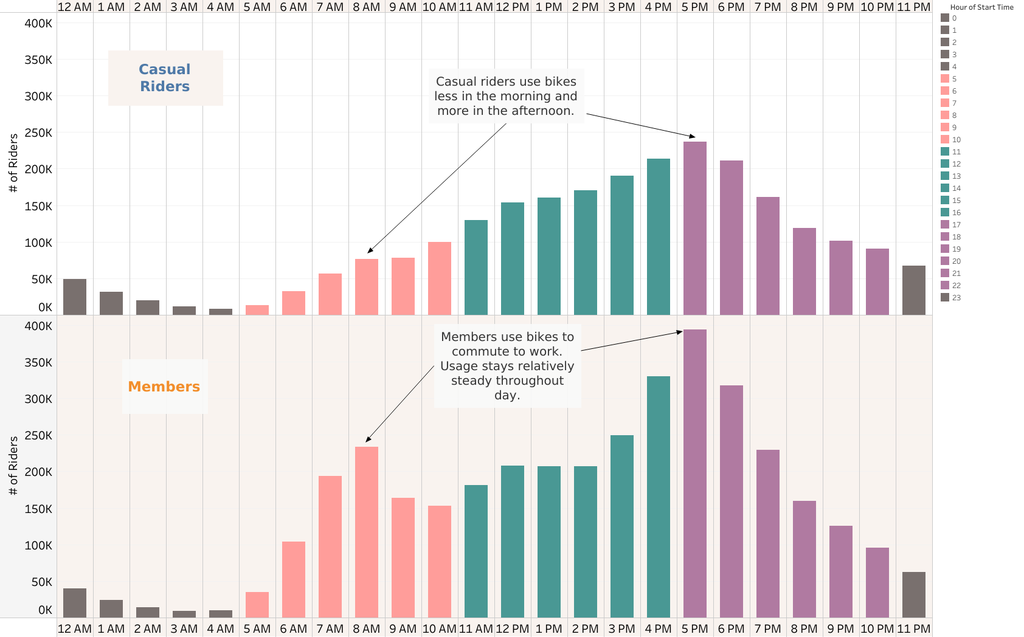

## What Days of the Week do Bikes get Most Usage?

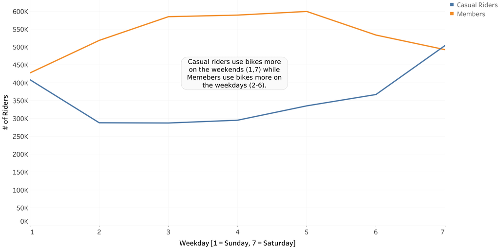

## Do Riders Prefer Standard or Electric Bikes?

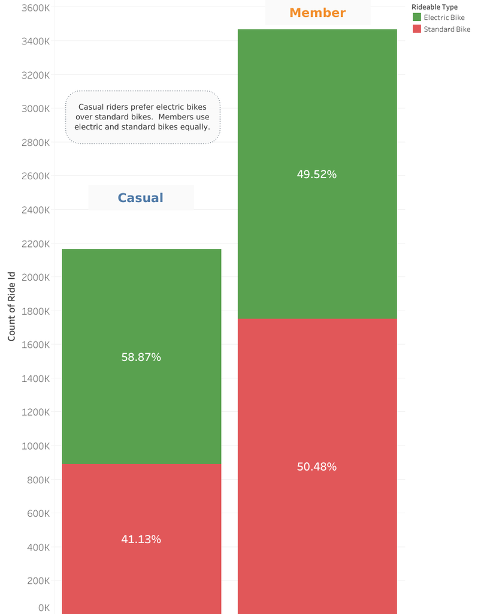

## What Months are the Most Popular for Riders?

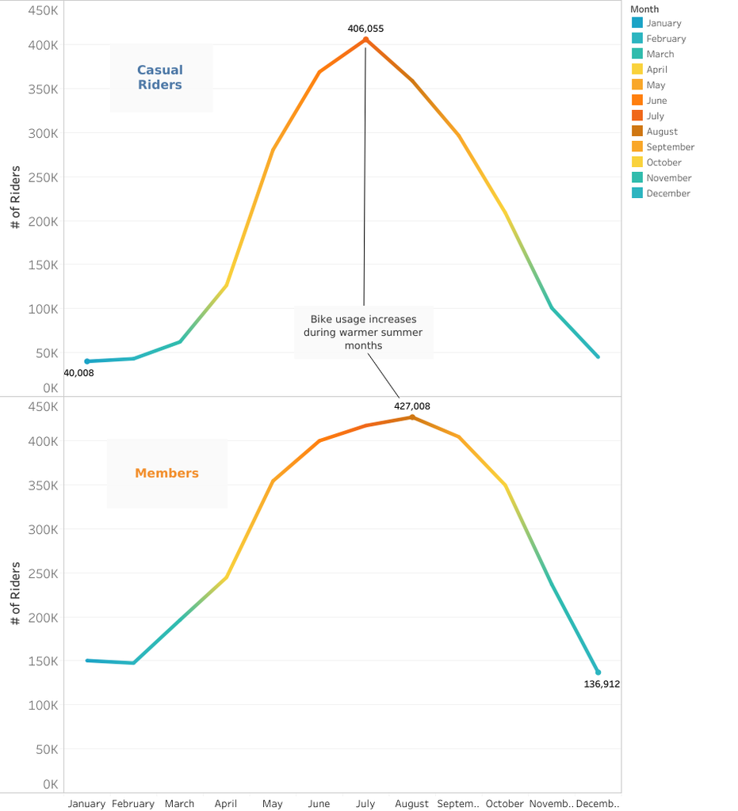

## What are the 7 Most Popular Stations for Riders to get Bikes?

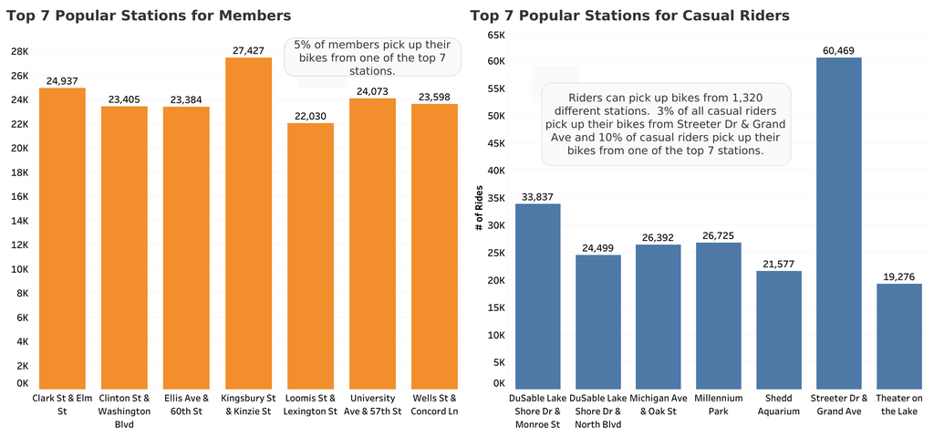